[figure not shown]

# Political Wikipedia Edit trends: Indicators for important events

## Data Science: CMPS 6160, Fall 2022

By Oliver Orejola

The website in which the analysis is located can be found [here](https://oliverorejolacmps3160.github.io.).

## Introduction

[Wikipedia](https://www.wikipedia.org) is an open source online encyclopedia, with the english wikipedia host to more than 6.5 million articles. With it being open source, many users are at liberty to make edits, updates, and changes to articles pertaining to a plethora of topics ranging from science, pop culture, politics and many more. Those who make edits may have many reasons, but ofcourse when an event happens one expects that editors flock to article relevant to particular event and make edits as to capture or reflect the news. In this project we set out to study the relationship of wikipedia edits made and important events. Here and through out, we restrict our consideration to a handful of political figures in the United States.

The goal of this project is to investigate time series trends in wikipedia page edits for key US political figures. In particular, we are interested in answer the question if wikipedia edits are indicators for importnat events. We address correlation between types of wikipedia edits made (Major, Minor, and IPs) and their relationship with *important* events. Moreover, we test a unsupervised model for classifying *important* events.

Since *important* event is a rather subjective notion, we measure the *importance* of a date with respect to a particular person, with the number of times that date appears on their wikipedia page. Although, we can rank *importance* with this number, through out we consider a date *importance* to be a binary class. That is, a date is considered *important* with respect to an individual, if that date appears *any where* on their wikipedia page.

We use a classic unsupervised learning technique, Isolation Forrests, to classify dates as *important*. We demonstrate that these models preform with high precision, but with low recall as our definition of *importance* is ill posed and over counts.

This Jupyter notebook is structured as follows:

- Datasets used (webscraped)
- Extract, Load, Transform
- Exploratory Analysis
  - Trends
  - Counts
  - Correlation
- Anomaly Detection
- Conclusion

## Project Datasets

The project considers two data web scraped from two seperate sources.

**Wikipedia Page Edits**

This data sets is scraped from https://xtools.wmflabs.org for a handful of wiki pages.

- Joe Biden - https://xtools.wmflabs.org/articleinfo/en.wikipedia.org/Joe_Biden
- Donald Trump - https://xtools.wmflabs.org/articleinfo/en.wikipedia.org/Donald_Trump
- Hillary Clinton - https://xtools.wmflabs.org/articleinfo/en.wikipedia.org/Hillary_Clinton
- Barack Obama - https://xtools.wmflabs.org/articleinfo/en.wikipedia.org/Barack_Obama
- Chuck Schumer- https://xtools.wmflabs.org/articleinfo/en.wikipedia.org/Chuck_Schumer
- Mitch McConnell- https://xtools.wmflabs.org/articleinfo/en.wikipedia.org/Mitch_McConnell

For each page the scraped data consists of the following information:

- month -- YYYY-MM
- Edits -- Total Number of Edits
- IPs -- Edits made while masking IP address
- IPs % -- Percentage of IP Edits
- Minor Edits -- Edits consider that only correct superficial differences exist between the current and previous version, e.g. typographical errors, formatting, etc.
- Minor Edits % -- Percentage of Minor Edits

**Dates found on Wikipedia Page** This data sets is scraped from https://en.wikipedia.org for the following individuals

- Joe Biden - https://en.wikipedia.org/wiki/Joe_Biden
- Donald Trump - https://en.wikipedia.org/wiki/Donald_Trump
- Hillary Clinton - https://en.wikipedia.org/wiki/Hillary_Clinton
- Barack Obama - https://en.wikipedia.org/wiki/Barack_Obama
- Chuck Schumer - https://en.wikipedia.org/wiki/Chuck_Schumer
- Mitch McConnell - https://en.wikipedia.org/wiki/Mitch_McConnell

For each page the scraped data consists of the following information only for the months present in the Wikipedia Page Edits data set:

- month -- YYYY-MM
- Found References - Number of references that cite the month and year
- Found Body - Number of paragraphs in the body of the page that cite the month and year
- Total Found - Total nuumber of citations the month and year that appear *anywhere* on the wikipedia page

## Extraction, Transform, and Load

### Extract

First, we extract the code from https://xtools.wmflabs.org and https://en.wikipedia.org/wiki/ for each of the wikipedia pages of interest. We then save the extracted data as `.csv` in the following format.

`PAGENAME_monthly_edits.csv`

```python
# Import relevant libraries For Extraction
import pandas as pd
import requests
from bs4 import BeautifulSoup
import re

# Define Header for request.get to bypass 403 error code
headers = {'User-Agent': 'Mozilla/5.0 (Macintosh; Intel Mac OS X 10_10_1) AppleWebKit/537.36 (KHTML, like Gecko) Chrome/39.0.2171.95 Safari/537.36'}

# List of wikipedia page names
page_names = ['Joe_Biden','Donald_Trump','Hillary_Clinton','Barack_Obama', 'Chuck_Schumer','Mitch_McConnell']
```

```python
# Create dictionary to to convert numerical month for searching web page for date
month_names = ['January', 'February', 'March','April',
               'May', 'June', 'July', 'August',
               'September', 'October','November', 'December']
month_number = list(range(1,13))
month_dict = dict(zip(month_number,month_names))

#Auxilary funciton to extract year nad month from date formated as str
def get_date(date):
    year = date[:4]
    month = month_dict[int(date[5:7])]
    return year, month
```

```python
##### ONLY RUN IF YOU WANT TO SCRAPE WEB DATA #####
for page in page_names:
    print('\n'+'-'*50)
    print(' '.join(page.split('_'))+ ' information scrape.')
    print('-'*50)
    url = ' https://xtools.wmflabs.org/articleinfo/en.wikipedia.org/'+page
    # Scrape web
    r = requests.get(url,headers=headers)
    print(f'Status code: {r.status_code} URL: {url}')
    soup = BeautifulSoup( r.content )

    # Find Tables
    df_tables = []
    for t in soup.findAll("table"):
        df_t = pd.read_html(str(t))
        df_tables.append(df_t[0])

    # Save Monthly Edits Table
    monthly_edits = df_tables[8]

    # Srape Wikipedia pages references and body for edit dates count the number of appearances of each date
    url_page = 'https://en.wikipedia.org/wiki/'+page
    # Scrape web
    r_page = requests.get(url_page,headers=headers)
    print(f'Status code: {r_page.status_code} URL: {url_page}')
    soup_page = BeautifulSoup( r_page.content )

    monthly_edits['Found References']=0
    monthly_edits['Found Body']=0


    for i, date in enumerate(monthly_edits['Month']):
        count_ref = 0
        count_body = 0
        year, month = get_date(str(date))

        #Search through references
        regex_ref = r"\(\b" + re.escape(month) + r"\b \d*. \b" + re.escape(year) +r"\)"
        c_ref=re.compile(regex_ref,re.I)  # with the ignorecase option
        for references in soup_page.findAll('ol'):
            ref = references.getText()
            split_ref = ref.split('\n')
            for item in split_ref:
                if len(c_ref.findall(item)):
                    count_ref +=1
        monthly_edits.at[i,"Found References"] += count_ref
        #Search through page body via paragraphs
        regex_body = r"\b" + re.escape(month) + r"\b \d*. \b" + re.escape(year)
        c_body=re.compile(regex_body,re.I)
        for paragraph in soup_page.findAll('p'):
            par = paragraph.getText()
            if len(c_body.findall(par)):
                count_body +=1
        monthly_edits.at[i,"Found Body"] += count_body

    print(f'Page searched for dates.')
    monthly_edits['Total Found']=monthly_edits['Found Body'] + monthly_edits['Found References']

    #Save File
    file_name = page+'_monthly_edits.csv'
    monthly_edits.to_csv(file_name, index=False)
```

```
--------------------------------------------------
Joe Biden information scrape.
--------------------------------------------------
Status code: 200 URL:  https://xtools.wmflabs.org/articleinfo/en.wikipedia.org/Joe_Biden
Status code: 200 URL: https://en.wikipedia.org/wiki/Joe_Biden
Page searched for dates.

--------------------------------------------------
Donald Trump information scrape.
--------------------------------------------------
Status code: 200 URL:  https://xtools.wmflabs.org/articleinfo/en.wikipedia.org/Donald_Trump
Status code: 200 URL: https://en.wikipedia.org/wiki/Donald_Trump
Page searched for dates.

--------------------------------------------------
Hillary Clinton information scrape.
--------------------------------------------------
Status code: 200 URL:  https://xtools.wmflabs.org/articleinfo/en.wikipedia.org/Hillary_Clinton
Status code: 200 URL: https://en.wikipedia.org/wiki/Hillary_Clinton
Page searched for dates.

--------------------------------------------------
Barack Obama information scrape.
--------------------------------------------------
Status code: 200 URL:  https://xtools.wmflabs.org/articleinfo/en.wikipedia.org/Barack_Obama
Status code: 200 URL: https://en.wikipedia.org/wiki/Barack_Obama
Page searched for dates.

--------------------------------------------------
Chuck Schumer information scrape.
--------------------------------------------------
Status code: 200 URL:  https://xtools.wmflabs.org/articleinfo/en.wikipedia.org/Chuck_Schumer
Status code: 200 URL: https://en.wikipedia.org/wiki/Chuck_Schumer
Page searched for dates.

--------------------------------------------------
Mitch McConnell information scrape.
--------------------------------------------------
Status code: 200 URL:  https://xtools.wmflabs.org/articleinfo/en.wikipedia.org/Mitch_McConnell
Status code: 200 URL: https://en.wikipedia.org/wiki/Mitch_McConnell
Page searched for dates.
```

### Load and Transform

Load the saved `PAGENAME_monthly_edits.csv` files for each page and look at the contents and check data types. Since we are dealing with multiple `.csv` files, one for each page. We save the files in a dictionary with the page name as the relevant key. This is done for to streamline edits for all datasets.

```python
# Init blank dict
dict_of_tables = dict()

for page in page_names:
    file_name = page+'_monthly_edits.csv'
    monthly_edits = pd.read_csv(file_name)
    dict_of_tables[page]=monthly_edits
    print('\n'+'-'*50)
    print(' '.join(page.split('_'))+ ' page data')
    print('-'*50)
    display(dict_of_tables[page])

    # Check data types
    print(dict_of_tables[page].dtypes,'\n')
```

```
--------------------------------------------------
Joe Biden page data
--------------------------------------------------
```

|  | Month | Edits | IPs | IPs % | Minor edits | Minor edits % | Edits · Minor edits · IPs | Found References | Found Body | Total Found |
| --- | --- | --- | --- | --- | --- | --- | --- | --- | --- | --- |
| 0 | 2002-11 | 1 | 0 | 0% | 1 | 100% | NaN | 0 | 0 | 0 |
| 1 | 2002-12 | 0 | 0 | 0% | 0 | 0% | NaN | 0 | 0 | 0 |
| 2 | 2003-01 | 0 | 0 | 0% | 0 | 0% | NaN | 0 | 0 | 0 |
| 3 | 2003-02 | 0 | 0 | 0% | 0 | 0% | NaN | 0 | 0 | 0 |
| 4 | 2003-03 | 0 | 0 | 0% | 0 | 0% | NaN | 0 | 0 | 0 |
| ... | ... | ... | ... | ... | ... | ... | ... | ... | ... | ... |
| 237 | 2022-08 | 114 | 0 | 0% | 21 | 18.4% | NaN | 13 | 3 | 16 |
| 238 | 2022-09 | 106 | 0 | 0% | 5 | 4.7% | NaN | 3 | 2 | 5 |
| 239 | 2022-10 | 37 | 0 | 0% | 12 | 32.4% | NaN | 3 | 1 | 4 |
| 240 | 2022-11 | 51 | 0 | 0% | 6 | 11.8% | NaN | 6 | 0 | 6 |
| 241 | 2022-12 | 62 | 0 | 0% | 17 | 27.4% | NaN | 2 | 1 | 3 |

242 rows × 10 columns

```
Month                             object
Edits                              int64
IPs                                int64
IPs %                             object
Minor edits                        int64
Minor edits %                     object
Edits  ·  Minor edits  ·  IPs    float64
Found References                   int64
Found Body                         int64
Total Found                        int64
dtype: object


--------------------------------------------------
Donald Trump page data
--------------------------------------------------
```

|  | Month | Edits | IPs | IPs % | Minor edits | Minor edits % | Edits · Minor edits · IPs | Found References | Found Body | Total Found |
| --- | --- | --- | --- | --- | --- | --- | --- | --- | --- | --- |
| 0 | 2004-01 | 6 | 0 | 0% | 4 | 66.7% | NaN | 0 | 0 | 0 |
| 1 | 2004-02 | 2 | 1 | 50% | 1 | 50% | NaN | 0 | 0 | 0 |
| 2 | 2004-03 | 1 | 0 | 0% | 0 | 0% | NaN | 0 | 0 | 0 |
| 3 | 2004-04 | 22 | 11 | 50% | 4 | 18.2% | NaN | 1 | 0 | 1 |
| 4 | 2004-05 | 10 | 4 | 40% | 1 | 10% | NaN | 0 | 0 | 0 |
| ... | ... | ... | ... | ... | ... | ... | ... | ... | ... | ... |
| 223 | 2022-08 | 215 | 0 | 0% | 22 | 10.2% | NaN | 11 | 1 | 12 |
| 224 | 2022-09 | 131 | 0 | 0% | 9 | 6.9% | NaN | 2 | 0 | 2 |
| 225 | 2022-10 | 190 | 0 | 0% | 7 | 3.7% | NaN | 0 | 0 | 0 |
| 226 | 2022-11 | 224 | 0 | 0% | 37 | 16.5% | NaN | 7 | 3 | 10 |
| 227 | 2022-12 | 81 | 0 | 0% | 13 | 16% | NaN | 0 | 0 | 0 |

228 rows × 10 columns

```
Month                             object
Edits                              int64
IPs                                int64
IPs %                             object
Minor edits                        int64
Minor edits %                     object
Edits  ·  Minor edits  ·  IPs    float64
Found References                   int64
Found Body                         int64
Total Found                        int64
dtype: object


--------------------------------------------------
Hillary Clinton page data
--------------------------------------------------
```

|  | Month | Edits | IPs | IPs % | Minor edits | Minor edits % | Edits · Minor edits · IPs | Found References | Found Body | Total Found |
| --- | --- | --- | --- | --- | --- | --- | --- | --- | --- | --- |
| 0 | 2001-03 | 2 | 0 | 0% | 0 | 0% | NaN | 0 | 0 | 0 |
| 1 | 2001-04 | 0 | 0 | 0% | 0 | 0% | NaN | 0 | 0 | 0 |
| 2 | 2001-05 | 0 | 0 | 0% | 0 | 0% | NaN | 0 | 0 | 0 |
| 3 | 2001-06 | 2 | 0 | 0% | 0 | 0% | NaN | 0 | 0 | 0 |
| 4 | 2001-07 | 4 | 0 | 0% | 0 | 0% | NaN | 0 | 0 | 0 |
| ... | ... | ... | ... | ... | ... | ... | ... | ... | ... | ... |
| 257 | 2022-08 | 4 | 0 | 0% | 1 | 25% | NaN | 0 | 0 | 0 |
| 258 | 2022-09 | 8 | 0 | 0% | 3 | 37.5% | NaN | 1 | 0 | 1 |
| 259 | 2022-10 | 8 | 0 | 0% | 3 | 37.5% | NaN | 0 | 0 | 0 |
| 260 | 2022-11 | 30 | 0 | 0% | 9 | 30% | NaN | 0 | 0 | 0 |
| 261 | 2022-12 | 1 | 0 | 0% | 1 | 100% | NaN | 0 | 0 | 0 |

262 rows × 10 columns

```
Month                             object
Edits                              int64
IPs                                int64
IPs %                             object
Minor edits                        int64
Minor edits %                     object
Edits  ·  Minor edits  ·  IPs    float64
Found References                   int64
Found Body                         int64
Total Found                        int64
dtype: object


--------------------------------------------------
Barack Obama page data
--------------------------------------------------
```

|  | Month | Edits | IPs | IPs % | Minor edits | Minor edits % | Edits · Minor edits · IPs | Found References | Found Body | Total Found |
| --- | --- | --- | --- | --- | --- | --- | --- | --- | --- | --- |
| 0 | 2004-03 | 4 | 1 | 25% | 0 | 0% | NaN | 5 | 0 | 5 |
| 1 | 2004-04 | 2 | 2 | 100% | 0 | 0% | NaN | 0 | 0 | 0 |
| 2 | 2004-05 | 0 | 0 | 0% | 0 | 0% | NaN | 2 | 0 | 2 |
| 3 | 2004-06 | 6 | 1 | 16.7% | 0 | 0% | NaN | 1 | 0 | 1 |
| 4 | 2004-07 | 82 | 18 | 22% | 36 | 43.9% | NaN | 6 | 0 | 6 |
| ... | ... | ... | ... | ... | ... | ... | ... | ... | ... | ... |
| 221 | 2022-08 | 39 | 0 | 0% | 17 | 43.6% | NaN | 0 | 0 | 0 |
| 222 | 2022-09 | 46 | 0 | 0% | 11 | 23.9% | NaN | 1 | 0 | 1 |
| 223 | 2022-10 | 37 | 0 | 0% | 4 | 10.8% | NaN | 0 | 0 | 0 |
| 224 | 2022-11 | 51 | 0 | 0% | 13 | 25.5% | NaN | 0 | 0 | 0 |
| 225 | 2022-12 | 18 | 0 | 0% | 13 | 72.2% | NaN | 0 | 0 | 0 |

226 rows × 10 columns

```
Month                             object
Edits                              int64
IPs                                int64
IPs %                             object
Minor edits                        int64
Minor edits %                     object
Edits  ·  Minor edits  ·  IPs    float64
Found References                   int64
Found Body                         int64
Total Found                        int64
dtype: object


--------------------------------------------------
Chuck Schumer page data
--------------------------------------------------
```

|  | Month | Edits | IPs | IPs % | Minor edits | Minor edits % | Edits · Minor edits · IPs | Found References | Found Body | Total Found |
| --- | --- | --- | --- | --- | --- | --- | --- | --- | --- | --- |
| 0 | 2003-09 | 2 | 1 | 50% | 0 | 0% | NaN | 0 | 0 | 0 |
| 1 | 2003-10 | 2 | 0 | 0% | 1 | 50% | NaN | 0 | 0 | 0 |
| 2 | 2003-11 | 0 | 0 | 0% | 0 | 0% | NaN | 0 | 0 | 0 |
| 3 | 2003-12 | 0 | 0 | 0% | 0 | 0% | NaN | 0 | 0 | 0 |
| 4 | 2004-01 | 0 | 0 | 0% | 0 | 0% | NaN | 0 | 0 | 0 |
| ... | ... | ... | ... | ... | ... | ... | ... | ... | ... | ... |
| 227 | 2022-08 | 4 | 0 | 0% | 0 | 0% | NaN | 0 | 0 | 0 |
| 228 | 2022-09 | 1 | 0 | 0% | 0 | 0% | NaN | 0 | 0 | 0 |
| 229 | 2022-10 | 2 | 0 | 0% | 1 | 50% | NaN | 0 | 0 | 0 |
| 230 | 2022-11 | 13 | 0 | 0% | 2 | 15.4% | NaN | 0 | 0 | 0 |
| 231 | 2022-12 | 2 | 0 | 0% | 0 | 0% | NaN | 0 | 0 | 0 |

232 rows × 10 columns

```
Month                             object
Edits                              int64
IPs                                int64
IPs %                             object
Minor edits                        int64
Minor edits %                     object
Edits  ·  Minor edits  ·  IPs    float64
Found References                   int64
Found Body                         int64
Total Found                        int64
dtype: object


--------------------------------------------------
Mitch McConnell page data
--------------------------------------------------
```

|  | Month | Edits | IPs | IPs % | Minor edits | Minor edits % | Edits · Minor edits · IPs | Found References | Found Body | Total Found |
| --- | --- | --- | --- | --- | --- | --- | --- | --- | --- | --- |
| 0 | 2003-10 | 1 | 0 | 0% | 0 | 0% | NaN | 0 | 0 | 0 |
| 1 | 2003-11 | 3 | 0 | 0% | 3 | 100% | NaN | 0 | 0 | 0 |
| 2 | 2003-12 | 3 | 0 | 0% | 2 | 66.7% | NaN | 0 | 0 | 0 |
| 3 | 2004-01 | 0 | 0 | 0% | 0 | 0% | NaN | 0 | 0 | 0 |
| 4 | 2004-02 | 0 | 0 | 0% | 0 | 0% | NaN | 0 | 0 | 0 |
| ... | ... | ... | ... | ... | ... | ... | ... | ... | ... | ... |
| 226 | 2022-08 | 6 | 0 | 0% | 1 | 16.7% | NaN | 0 | 0 | 0 |
| 227 | 2022-09 | 1 | 0 | 0% | 0 | 0% | NaN | 0 | 0 | 0 |
| 228 | 2022-10 | 8 | 0 | 0% | 1 | 12.5% | NaN | 0 | 0 | 0 |
| 229 | 2022-11 | 20 | 0 | 0% | 7 | 35% | NaN | 0 | 0 | 0 |
| 230 | 2022-12 | 3 | 0 | 0% | 1 | 33.3% | NaN | 0 | 0 | 0 |

231 rows × 10 columns

```
Month                             object
Edits                              int64
IPs                                int64
IPs %                             object
Minor edits                        int64
Minor edits %                     object
Edits  ·  Minor edits  ·  IPs    float64
Found References                   int64
Found Body                         int64
Total Found                        int64
dtype: object
```

These columns `IPs %`, `Minor edits %` and `Edits Minor Edits IPs` do not mean anything for our analysis so we drop them. In addition, we convert the Month to a relevant `datetime` format.

```python
relevant_columns = ['Month', 'Edits','IPs', 'Minor edits','Found References','Found Body','Total Found' ]
for page in page_names:
    print('\n'+'-'*50)
    print(' '.join(page.split('_'))+ ' page data')
    print('-'*50)

    monthly_edits = dict_of_tables[page]

    # Get relevant columns
    monthly_edits=monthly_edits.loc[:,relevant_columns]

    # Add Major edits column
    monthly_edits['Major'] = monthly_edits['Edits'] - monthly_edits['IPs'] - monthly_edits['Minor edits']

    #Rearange columns
    monthly_edits = monthly_edits[ ['Month', 'Edits','Major','IPs', 'Minor edits','Total Found','Found References','Found Body' ]]
    # Convert Month to date time
    monthly_edits['Month'] = pd.to_datetime(monthly_edits['Month'], format='%Y-%m')
    dict_of_tables[page]=monthly_edits
    display(dict_of_tables[page].head())
    print(dict_of_tables[page].dtypes)
```

```
--------------------------------------------------
Joe Biden page data
--------------------------------------------------
```

|  | Month | Edits | Major | IPs | Minor edits | Total Found | Found References | Found Body |
| --- | --- | --- | --- | --- | --- | --- | --- | --- |
| 0 | 2002-11-01 | 1 | 0 | 0 | 1 | 0 | 0 | 0 |
| 1 | 2002-12-01 | 0 | 0 | 0 | 0 | 0 | 0 | 0 |
| 2 | 2003-01-01 | 0 | 0 | 0 | 0 | 0 | 0 | 0 |
| 3 | 2003-02-01 | 0 | 0 | 0 | 0 | 0 | 0 | 0 |
| 4 | 2003-03-01 | 0 | 0 | 0 | 0 | 0 | 0 | 0 |

```
Month               datetime64[ns]
Edits                        int64
Major                        int64
IPs                          int64
Minor edits                  int64
Total Found                  int64
Found References             int64
Found Body                   int64
dtype: object

--------------------------------------------------
Donald Trump page data
--------------------------------------------------
```

|  | Month | Edits | Major | IPs | Minor edits | Total Found | Found References | Found Body |
| --- | --- | --- | --- | --- | --- | --- | --- | --- |
| 0 | 2004-01-01 | 6 | 2 | 0 | 4 | 0 | 0 | 0 |
| 1 | 2004-02-01 | 2 | 0 | 1 | 1 | 0 | 0 | 0 |
| 2 | 2004-03-01 | 1 | 1 | 0 | 0 | 0 | 0 | 0 |
| 3 | 2004-04-01 | 22 | 7 | 11 | 4 | 1 | 1 | 0 |
| 4 | 2004-05-01 | 10 | 5 | 4 | 1 | 0 | 0 | 0 |

```
Month               datetime64[ns]
Edits                        int64
Major                        int64
IPs                          int64
Minor edits                  int64
Total Found                  int64
Found References             int64
Found Body                   int64
dtype: object

--------------------------------------------------
Hillary Clinton page data
--------------------------------------------------
```

|  | Month | Edits | Major | IPs | Minor edits | Total Found | Found References | Found Body |
| --- | --- | --- | --- | --- | --- | --- | --- | --- |
| 0 | 2001-03-01 | 2 | 2 | 0 | 0 | 0 | 0 | 0 |
| 1 | 2001-04-01 | 0 | 0 | 0 | 0 | 0 | 0 | 0 |
| 2 | 2001-05-01 | 0 | 0 | 0 | 0 | 0 | 0 | 0 |
| 3 | 2001-06-01 | 2 | 2 | 0 | 0 | 0 | 0 | 0 |
| 4 | 2001-07-01 | 4 | 4 | 0 | 0 | 0 | 0 | 0 |

```
Month               datetime64[ns]
Edits                        int64
Major                        int64
IPs                          int64
Minor edits                  int64
Total Found                  int64
Found References             int64
Found Body                   int64
dtype: object

--------------------------------------------------
Barack Obama page data
--------------------------------------------------
```

|  | Month | Edits | Major | IPs | Minor edits | Total Found | Found References | Found Body |
| --- | --- | --- | --- | --- | --- | --- | --- | --- |
| 0 | 2004-03-01 | 4 | 3 | 1 | 0 | 5 | 5 | 0 |
| 1 | 2004-04-01 | 2 | 0 | 2 | 0 | 0 | 0 | 0 |
| 2 | 2004-05-01 | 0 | 0 | 0 | 0 | 2 | 2 | 0 |
| 3 | 2004-06-01 | 6 | 5 | 1 | 0 | 1 | 1 | 0 |
| 4 | 2004-07-01 | 82 | 28 | 18 | 36 | 6 | 6 | 0 |

```
Month               datetime64[ns]
Edits                        int64
Major                        int64
IPs                          int64
Minor edits                  int64
Total Found                  int64
Found References             int64
Found Body                   int64
dtype: object

--------------------------------------------------
Chuck Schumer page data
--------------------------------------------------
```

|  | Month | Edits | Major | IPs | Minor edits | Total Found | Found References | Found Body |
| --- | --- | --- | --- | --- | --- | --- | --- | --- |
| 0 | 2003-09-01 | 2 | 1 | 1 | 0 | 0 | 0 | 0 |
| 1 | 2003-10-01 | 2 | 1 | 0 | 1 | 0 | 0 | 0 |
| 2 | 2003-11-01 | 0 | 0 | 0 | 0 | 0 | 0 | 0 |
| 3 | 2003-12-01 | 0 | 0 | 0 | 0 | 0 | 0 | 0 |
| 4 | 2004-01-01 | 0 | 0 | 0 | 0 | 0 | 0 | 0 |

```
Month               datetime64[ns]
Edits                        int64
Major                        int64
IPs                          int64
Minor edits                  int64
Total Found                  int64
Found References             int64
Found Body                   int64
dtype: object

--------------------------------------------------
Mitch McConnell page data
--------------------------------------------------
```

|  | Month | Edits | Major | IPs | Minor edits | Total Found | Found References | Found Body |
| --- | --- | --- | --- | --- | --- | --- | --- | --- |
| 0 | 2003-10-01 | 1 | 1 | 0 | 0 | 0 | 0 | 0 |
| 1 | 2003-11-01 | 3 | 0 | 0 | 3 | 0 | 0 | 0 |
| 2 | 2003-12-01 | 3 | 1 | 0 | 2 | 0 | 0 | 0 |
| 3 | 2004-01-01 | 0 | 0 | 0 | 0 | 0 | 0 | 0 |
| 4 | 2004-02-01 | 0 | 0 | 0 | 0 | 0 | 0 | 0 |

```
Month               datetime64[ns]
Edits                        int64
Major                        int64
IPs                          int64
Minor edits                  int64
Total Found                  int64
Found References             int64
Found Body                   int64
dtype: object
```

Now consider the average statiscs for each page.

```python
for page in page_names:

    monthly_edits = dict_of_tables[page][['Edits','IPs', 'Minor edits','Total Found', 'Found Body', 'Found References']]
    print('\n'+'-'*50)
    print(' '.join(page.split('_'))+ ' page data summary')
    print('-'*50)
    print(monthly_edits.describe(datetime_is_numeric=True))
```

```
--------------------------------------------------
Joe Biden page data summary
--------------------------------------------------
            Edits         IPs  Minor edits  Total Found  Found Body  \
count  242.000000  242.000000   242.000000   242.000000  242.000000
mean    45.231405    3.140496     9.822314     1.599174    0.107438
std     97.623611   11.855846    24.010834     2.915205    0.392918
min      0.000000    0.000000     0.000000     0.000000    0.000000
25%      7.000000    0.000000     1.000000     0.000000    0.000000
50%     17.500000    0.000000     4.000000     0.000000    0.000000
75%     39.750000    0.000000    10.000000     2.000000    0.000000
max    913.000000  136.000000   286.000000    20.000000    3.000000

       Found References
count        242.000000
mean           1.491736
std            2.695073
min            0.000000
25%            0.000000
50%            0.000000
75%            2.000000
max           19.000000

--------------------------------------------------
Donald Trump page data summary
--------------------------------------------------
             Edits         IPs  Minor edits  Total Found  Found Body  \
count   228.000000  228.000000   228.000000   228.000000  228.000000
mean    173.925439   11.592105    35.337719     3.236842    0.131579
std     232.323428   26.092437    51.270939     5.724671    0.593847
min       0.000000    0.000000     0.000000     0.000000    0.000000
25%      23.000000    0.000000     6.000000     0.000000    0.000000
50%      84.500000    0.000000    16.500000     0.000000    0.000000
75%     227.000000   10.250000    43.000000     5.000000    0.000000
max    1475.000000  131.000000   373.000000    43.000000    6.000000

       Found References
count        228.000000
mean           3.105263
std            5.380448
```

[output cut: 82 more lines]

```
min      0.000000    0.000000     0.000000     0.000000    0.000000
25%      6.000000    0.000000     1.000000     0.000000    0.000000
50%     14.000000    2.000000     3.000000     0.000000    0.000000
75%     27.000000    7.000000     6.000000     1.000000    0.000000
max    139.000000   47.000000    47.000000    13.000000    2.000000

       Found References
count        231.000000
mean           0.610390
std            1.352831
min            0.000000
25%            0.000000
50%            0.000000
75%            1.000000
max           12.000000
```

## Exploratory Data Analysis: Edit Trends

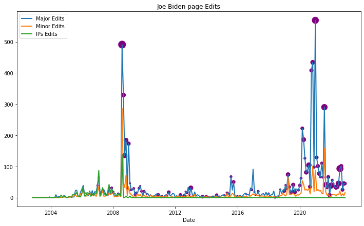

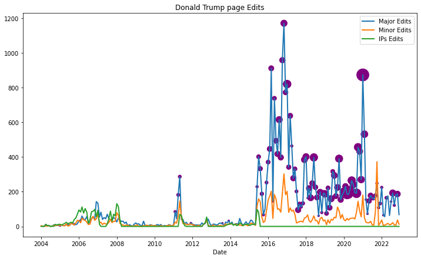

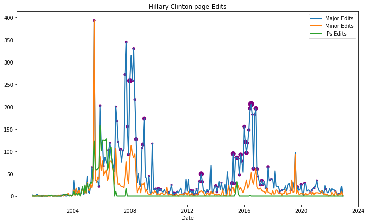

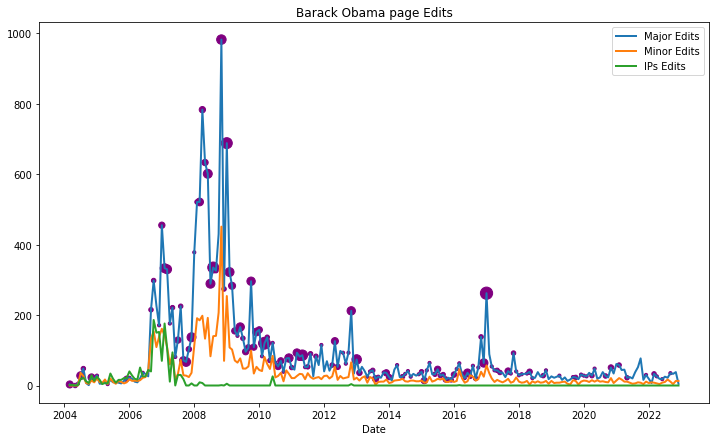

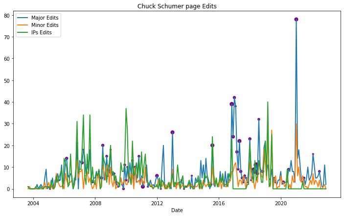

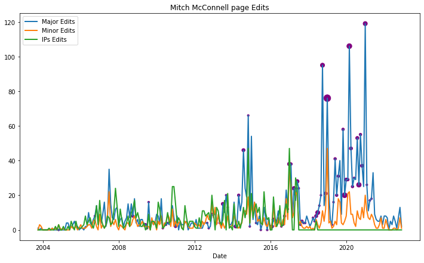

```python
import matplotlib.pyplot as plt
import datetime as dt

plt.rcParams['figure.figsize'] = [12, 7]
for page in page_names:
    monthly_edits = dict_of_tables[page]

    fig, ax = plt.subplots()
    ax.plot(monthly_edits['Month'], monthly_edits['Major'], linewidth=2.0)
    ax.plot(monthly_edits['Month'], monthly_edits['Minor edits'], linewidth=2.0)
    ax.plot(monthly_edits['Month'], monthly_edits['IPs'], linewidth=2.0)
    ax.scatter(monthly_edits['Month'], monthly_edits['Major'],
           s=monthly_edits['Total Found']*10,marker='o', c ='purple'  )

    ax.legend(['Major Edits','Minor Edits','IPs Edits','Dates Found'])

    ax.legend(['Major Edits','Minor Edits','IPs Edits'])
    plt.xlabel('Date')
    plt.title(' '.join(page.split('_'))+' page Edits')
    plt.show()
```

We see there are some repeating 'spikes' whcih may suggest preiodicity. The natural guess is that these spikes occur near importiant political dates. Interestingly enough, where there is a large activity of edits, we see theere are also many cited dates. Suggesting, at least visually, the number of edits relates to presence of a citation on that date.

## Exploritory Data Analysis: Important Dates

We now consider what are the events that occured on a given date for a specific page. The following function takes in a page name as well as month and year of interest, then prints out all the citations in both the body of the wikipedia page as well as references.

```python
def print_date_info(date,page):

    url_page = 'https://en.wikipedia.org/wiki/'+page
    # Scrape web
    r_page = requests.get(url_page,headers=headers)
    #print(f'Status code: {r_page.status_code} URL: {url_page}')
    soup_page = BeautifulSoup( r_page.content )

    year, month = get_date(str(date))

    #Search through references
    regex_ref = r"\(\b" + re.escape(month) + r"\b \d*. \b" + re.escape(year) +r"\)"
    c_ref=re.compile(regex_ref,re.I)  # with the ignorecase option
    found_ref = False
    print('Searching References...\n')
    for references in soup_page.findAll('ol'):
        ref = references.getText()
        split_ref = ref.split('\n')
        for item in split_ref:
            if len(c_ref.findall(item)):
                reference_Date = re.findall(r'\(.*\)',item)[0]
                reference_title = re.findall(r'["].*["]',item)[0]
                print(reference_Date+' '+ reference_title)
                found_ref = True
    if not found_ref:
        print('No date in references found.')
    #Search through page body via paragraphs
    regex_body = r"\b" + re.escape(month) + r"\b \d*. \b" + re.escape(year)

    found_body = False
    c_body=re.compile(regex_body,re.I)
    print('\nSearching body...\n')
    for paragraph in soup_page.findAll('p'):
        par = paragraph.getText()
        if len(c_body.findall(par)):
                print(par)
                found_body=True
    if not found_body:
        print('No date in body found.')
```

#### Proportion of Edits

First we consider a histogram of the number of edits per day. That is, in the figure below we plot the proportion of edits per day for each page of interest. We then report the information found on each date with the maximum number of edits.

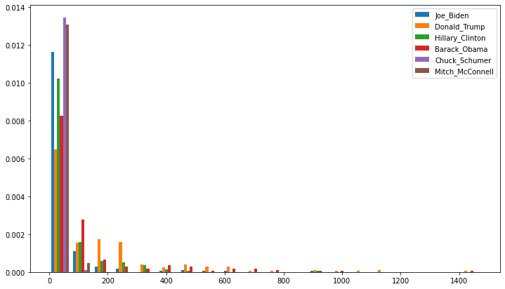

```python
list_of_counts = []
nbins=20
for page in page_names:
    monthly_edits =dict_of_tables[page]
    found_count = monthly_edits['Edits']
    list_of_counts.append(found_count)

plt.hist(list_of_counts,nbins,density=True, histtype='bar')
plt.legend(page_names)
plt.show()
```

```python
for page in page_names:
    monthly_edits = dict_of_tables[page]
    max_edit_entry =monthly_edits.sort_values(by = 'Edits',ascending=False).iloc[0]
    print('-'*50)
    print(' '.join(page.split('_'))+ ' Max edits')
    print('-'*50)
    print(max_edit_entry['Month'])
    print('Number of edits:', max_edit_entry['Edits'])
    print('Number of citations found in references:', max_edit_entry['Found References'])
    print('Number of citations found in body:', max_edit_entry['Found Body'])
    print_date_info(max_edit_entry['Month'],page)
```

```
--------------------------------------------------
Joe Biden Max edits
--------------------------------------------------
2008-08-01 00:00:00
Number of edits: 913
Number of citations found in references: 19
Number of citations found in body: 1
Searching References...

(August 27, 2008) "Biden's Scranton childhood left lasting impression"
(August 24, 2008) "In his home state, Biden is a regular Joe"
(August 24, 2008) "Jill Biden Heads Toward Life in the Spotlight"
(August 25, 2008) "Parishioners not surprised to see Biden at usual Mass"
(August 20, 2008) "Biden's Foreign Policy Background Carries Growing Cachet"
(August 26, 2008) "For Widener Law students, a teacher aims high"
(August 27, 2008) "Widener students proud of Biden"
(August 24, 2008) "In Biden, Obama chooses a foreign policy adherent of diplomacy before force"
(August 23, 2008) "V.P. candidate profile: Sen. Joe Biden"
(August 23, 2008) "Biden and Anita Hill, Revisited"
(August 24, 2008) "Joe Biden respected—if not always popular—for foreign policy record"
(August 25, 2008) "Biden, McCain Have a Friendship—and More—in Common"
(August 23, 2008) "Obama's veep message to supporters"
(August 23, 2008) "Obama Chooses Biden as Running Mate"
(August 25, 2008) "Tramps Like Us: How Joe Biden will reassure working class voters and change the tenor of this week's convention"
(August 27, 2008) "Biden accepts VP nomination"
(August 24, 2008) "Biden Wages 2 Campaigns At Once"
(August 24, 2008) "Demographics part of calculation: Biden adds experience, yes, but he could also help with Catholics, blue-collar whites and women"
(August 23, 2008) "Halperin on Biden: Pros and Cons"

Searching body...

Shortly after Biden withdrew from the presidential race, Obama privately told him he was interested in finding an important place for Biden in his administration.[170] In early August, Obama and Biden met in secret to discuss the possibility,[170] and developed a strong personal rapport.[169] On Aug…

--------------------------------------------------
Donald Trump Max edits
--------------------------------------------------
2016-11-01 00:00:00
Number of edits: 1475
Number of citations found in references: 11
Number of citations found in body: 1
```

[output cut: 78 more lines]

```
--------------------------------------------------
2021-01-01 00:00:00
Number of edits: 139
Number of citations found in references: 4
Number of citations found in body: 1
Searching References...

(January 6, 2021) "Analysis | Mitch McConnell's forceful rejection of Trump's election 'conspiracy theories'"
(January 6, 2021) "Resuming electoral counting, McConnell condemns the mob assault on the Capitol as a 'failed insurrection.'"
(January 12, 2021) "McConnell is said to be pleased about impeachment, believing it will be easier to purge Trump from the G.O.P."
(January 13, 2021) "McConnell won't agree to reconvene Senate early for impeachment trial"

Searching body...

On January 12, 2021, it was reported that McConnell supported impeaching Trump for his role in inciting the 2021 storming of the United States Capitol, believing it would make it easier for Republicans to purge the party of Trump and rebuild the party.[94] On January 13, despite having the authority…
```

Reading the report we see that the dates where the maximum number of edits occured all have citations for noteworthy events. Cherry picking a few, we see that for Joe Biden, the month of maximum edits was August 2008, in particular this is when it was announced he would be Obama's running mate. On Donald Trumps page, we see that the month of maximum edits is November 2016, this is the month he won the US presidential election. Similarly, on Barack Obama's page the month of maximum edits is November 2008, when Obama won the US presidential election. This number consistent with our hypothesis that wikipedia trends are indiciative of important events.

#### Proportion of Counts

We consider a histogram of the number of citations for a day. That is, in the figure below we plot the proportion of citation each day recieves for each page of interest. We then report the information found on each date with the maximum number of citations.

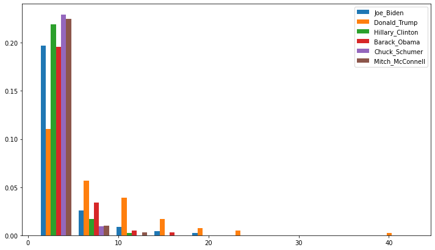

```python
list_of_counts = []
nbins=10
for page in page_names:
    monthly_edits =dict_of_tables[page]
    found_count = monthly_edits[monthly_edits['Total Found']!=0]['Total Found']
    list_of_counts.append(found_count)

plt.hist(list_of_counts,nbins,density=True, histtype='bar')
plt.legend(page_names)
plt.show()
```

```python
for page in ['Donald_Trump', 'Joe_Biden', 'Barack_Obama','Mitch_McConnell']:
    monthly_edits = dict_of_tables[page]
    max_edit_entry =monthly_edits.sort_values(by = 'Total Found',ascending=False).iloc[0]
    print('-'*50)
    print(' '.join(page.split('_'))+ ' Max Citation')
    print('-'*50)
    print(max_edit_entry['Month'])
    print('Number of edits:', max_edit_entry['Edits'])
    print('Number of citations found in references:', max_edit_entry['Found References'])
    print('Number of citations found in body:', max_edit_entry['Found Body'])
    print_date_info(max_edit_entry['Month'],page)
```

```
--------------------------------------------------
Donald Trump Max Citation
--------------------------------------------------
2021-01-01 00:00:00
Number of edits: 1055
Number of citations found in references: 37
Number of citations found in body: 6
Searching References...

(January 20, 2021) "Trump's presidency ends where so much of it was spent: A Trump Organization property"
(January 12, 2021) "Deutsche Bank won't do any more business with Trump"
(January 25, 2021) "Supreme Court dismisses emoluments cases against Trump"
(January 8, 2021) "Trump will have the worst jobs record in modern U.S. history. It's not just the pandemic"
(January 14, 2021). "Donald Trump Built a National Debt So Big (Even Before the Pandemic) "Donald Trump Built a National Debt So Big (Even Before the Pandemic) That It'll Weigh Down the Economy for Years"
(January 30, 2021) "From building the wall to bringing back coal: Some of Trump's more notable broken promises"
(January 20, 2021) "The Trump Administration Rolled Back More Than 100 Environmental Rules. Here's the Full List"
(January 16, 2021) "In Trump's final days, a rush of federal executions"
(January 15, 2021) "Trump administration carries out 13th and final execution"
(January 20, 2021) "With Hours Left in Office, Trump Grants Clemency to Bannon and Other Allies"
(January 13, 2021) "Fact check: Mexico never paid for it. But what about Trump's other border wall promises?"
(January 13, 2021) "How Trump compares with other recent presidents in appointing federal judges"
(January 3, 2021) "'I just want to find 11,780 votes': In extraordinary hour-long call, Trump pressures Georgia secretary of state to recalculate the vote in his favor"
(January 5, 2021) "Pence Said to Have Told Trump He Lacks Power to Change Election Result"
(January 20, 2021) "Trump Departs Vowing, 'We Will Be Back in Some Form'"
(January 10, 2021) "Incitement to Riot? What Trump Told Supporters Before Mob Stormed Capitol"
(January 9, 2021) "How one of America's ugliest days unraveled inside and outside the Capitol"
(January 6, 2021) "Facebook, Twitter lock Trump's account following video addressing Washington rioters"
(January 6, 2021) "Calls grow for social media platforms to silence Trump as rioters storm US Capitol"
(January 6, 2021) "Congress confirms Biden's win after pro-Trump mob's assault on Capitol"
(January 11, 2021) "Impeachment Resolution Cites Trump's 'Incitement' of Capitol Insurrection"
(January 13, 2021) "Trump Impeached for Inciting Insurrection"
(January 13, 2021) "House calls on Pence to invoke 25th Amendment, but he's already dismissed the idea"
(January 13, 2021) "Trump's second impeachment is the most bipartisan one in history"
(January 28, 2021) "Palm Beach considers options as Trump remains at Mar-a-Lago"
(January 27, 2021) "Explainer: Why Trump's post-presidency perks, like a pension and office, are safe for the rest of his life"
(January 27, 2021) "Trump opens "Office of the Former President" in Florida"
(January 18, 2021) "Last Trump Job Approval 34%; Average Is Record-Low 41%"
(January 16, 2021) "Trump finishes with worst first term approval rating ever"
(January 16, 2021) "Inside Twitter's Decision to Cut Off Trump"
(January 9, 2021) "A farewell to @realDonaldTrump, gone after 57,000 tweets"
```

[output cut: 94 more lines]

```
(January 2, 2019) "McConnell suggests shutdown could last for weeks"
(January 4, 2019) "McConnell keeps his head down as government shutdown drags on"
(January 10, 2019) "Senate Democrats pushed a vote to reopen the government. Mitch McConnell shot them down"
(January 11, 2019) "Mitch McConnell could end the shutdown. But he's sitting this one out"
(January 23, 2019) "McConnell blocks bill to reopen most of government"
(January 25, 2019) "'This is your fault': GOP senators clash over shutdown inside private luncheon"
(January 3, 2019) "McConnell Faces Pressure From Republicans to Stop Avoiding Shutdown Fight"
(January 25, 2019) "Trump signs bill to end shutdown and temporarily reopen government"
(January 9, 2019) "The Government Shutdown Was the Longest Ever. Here's the History"
(January 10, 2019) "America's Most and Least Popular Senators: McConnell loses spot as least popular senator"
(January 22, 2019) "Mitch McConnell Got Everything He Wanted. But at What Cost?"

Searching body...

From December 22, 2018, until January 25, 2019, the federal government was shut down when Congress refused to give in to Trump's demand for $5.7 billion in federal funds for a U.S.–Mexico border wall.[142] In December 2018, the Republican-controlled Senate unanimously passed an appropriations bill w…
```

Above we consider the dates with the maximum number of citations for a few select pages. On Donald Trump's page we have January 2021, the infmamous attack on the US capitol. An event spurred by the former President of the US. For Joe Biden, we have again August 2008 when he was announced to be Obama's running mate. On Barack Obama's page we have January 2017, the end of his second term. For Mitch McConnell, the most cited month is January 2019. His credited for prolonging the federal goverment shutdown.

## Exploritory Data Analysis: Correlations

A natural quesiton to ask is if the number of edits are correlated to the number of references of a particular date. In particular, we expect that the number of `Minor edits` is correlated with the number of `Major edits`. This is observed in our time series plots of the edits for each page. Below we plot a heat map of the pearson correlation coefficient between the total number of citations of a particular date, the number of minor edits, the number of ip edits and the number of major edits.

```python
# Combine all the dataframes of data for each page
combined_df = pd.concat(dict_of_tables.values(),ignore_index=True)
```

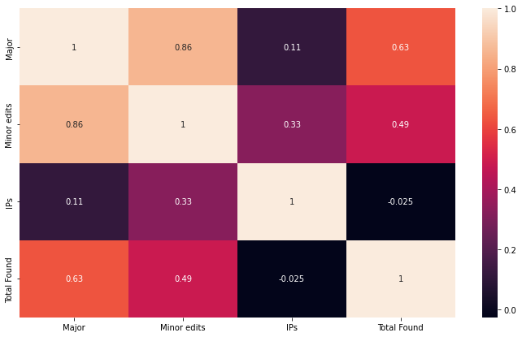

```python
import seaborn as sns

sns.heatmap(combined_df[['Major','Minor edits','IPs','Total Found']].corr(), annot=True)
plt.show()
```

Based on the correlation heat map above it is clear that `IPs edits` are not *highly* correlated with any variable. Moreover, the plot confirms our natural guess that `Minor Edits` are *highly* correlated with `Major Edits`. We also observe that `Major edits` and `Minor edits` are correlated with the number of citations found. This correlation suggests, *mildly*, that edits are indicitave of *important* events.

## Anomaly Detection: Donald Trump

We now implement an unsupervised Anomaly Detection algorithm to detect *important* dates. In particular, here we make use of an algorithm known as Isolation Forests. More information on Isolation Forests can be found [here](https://scikit-learn.org/stable/modules/generated/sklearn.ensemble.IsolationForest.html).

For our models inputs, we only make use of a page's `Major Edits` and `Minor Edits`. We neglect using `IPs Edits` as they do not carry much predictive power as suggested by our correlation analysis. We can measure the performace of our model by comparing dates classified as *important* with the presence of citations for that date. That is, a date is *important* if that date has any citations on the page. (It should be noted that this is a weak measure of *importnance*. Namely, this suggests a date with one citation is as important as a date with 50.)

```python
from sklearn.ensemble import IsolationForest
import numpy as np

page = 'Donald_Trump'
df = dict_of_tables[page]


X = np.array(df[['Major','Minor edits']])
# Fit Isolation Forest Model
clf = IsolationForest(random_state=0).fit(X)
# Predict
anomaly_predicted =  clf.predict(X)

predicted = df[anomaly_predicted == -1]

# Define important class as those with at least 1 citation
y_important = [(-1)**int(x) for x in df['Total Found']!=0]
```

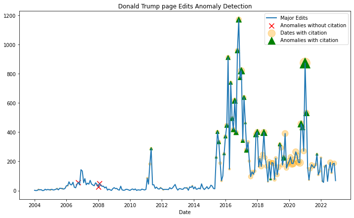

```python
fig, ax = plt.subplots()
#important_date = dt.datetime(2021, 1, 6)

ax.plot(df['Month'], df['Major'],linestyle='-', linewidth=2.0)

ax.scatter(predicted[predicted['Total Found']==0]['Month'], predicted[predicted['Total Found']==0]['Major'],
           s=100,marker='x', c ='red'  )

ax.scatter(df['Month'], df['Major'],
           s = df['Total Found']*10,marker='o', c ='orange',alpha=0.35  )
ax.scatter(predicted['Month'], predicted['Major'],
           s = predicted['Total Found']*10,marker='^', c ='green'  )

plt.legend(['Major Edits','Anomalies without citation','Dates with citation','Anomalies with citation'])

plt.xlabel('Date')
plt.title(' '.join(page.split('_'))+' page Edits Anomaly Detection')
plt.show()
```

In the plot above we mark with green triangles the dates labeled as anomalies with citation, the size of triangle corresponds to how many citations that date has. That is, the larger the triangle, the more citations, the more important. The rex crosses denote dates that were classified as anomalies but have no citations. Namely, we consider those to be false positives or incorrectly labeled importnat dates. The orange circle mark all dates that have any citation, the size corresponds to the number of citations for that date.

We now plot the confusion matrix below.

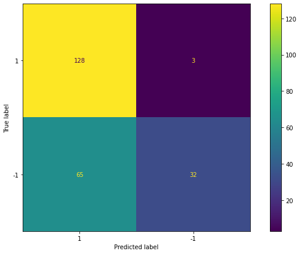

```python
from sklearn.metrics import confusion_matrix, ConfusionMatrixDisplay

cm = confusion_matrix(y_important, anomaly_predicted, labels =[1,-1])
disp = ConfusionMatrixDisplay(confusion_matrix=cm ,display_labels =[1,-1])
disp.plot()
plt.show()
```

```python
recall = cm[1,1] / np.sum(cm, axis = 1)[1]
precision = cm[1,1] / np.sum(cm, axis = 0)[1]
F1_score = 2*(precision*recall)/(precision+recall)
print(f'Precision: {precision:.2f}')
print(f'Recall: {recall:.2f}')
print(f'F1 Score: {F1_score:.2f}')
```

```
Precision: 0.91
Recall: 0.33
F1 Score: 0.48
```

We observe for Donald Trumps page, the IsolatedForest model has high precision but low recall. This leads to a moderate F1 Score. This is due to the fact that there are many dates *important* dates with 1 citation. In turn, the model fails to capture them.

```python
pred_average=predicted['Total Found'].mean()
print(f' Average number of citation for predicted dates {pred_average:.2f}')
```

```
 Average number of citation for predicted dates 8.54
```

We see that the average number of citations for a page predicted to be *important* is fairly high. It's no suprize that we mis classyfing dates with 1 citation.

## Anomlay Detection: Other Pages

We now repeat this for all other pages.

```
--------------------------------------------------
Joe Biden Page Model
--------------------------------------------------
```

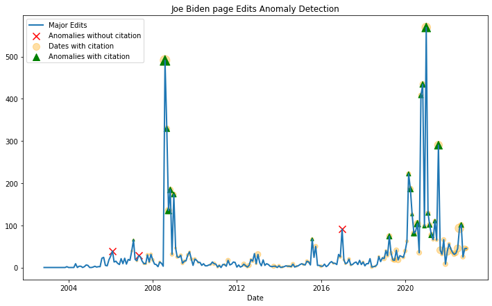

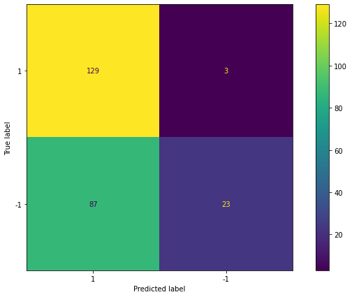

```
Precision: 0.88
Recall: 0.21
F1 Score: 0.34
Average number of citation for predicted dates 5.85

--------------------------------------------------
Donald Trump Page Model
--------------------------------------------------
```

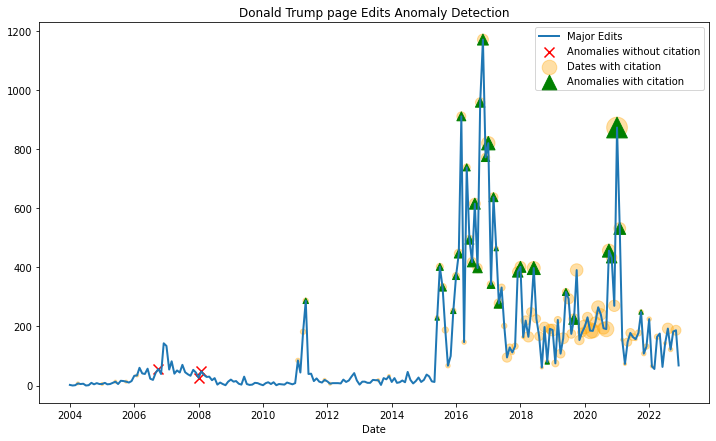

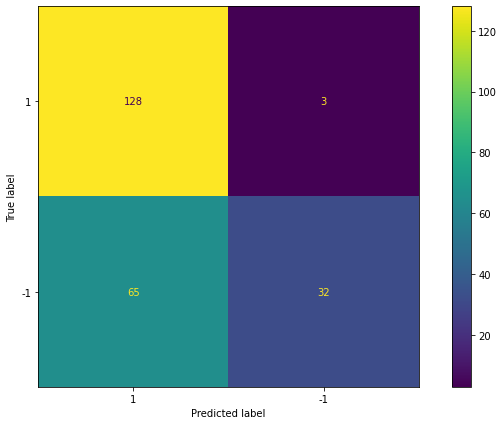

```
Precision: 0.91
Recall: 0.33
F1 Score: 0.48
Average number of citation for predicted dates 8.54

--------------------------------------------------
Hillary Clinton Page Model
--------------------------------------------------
```

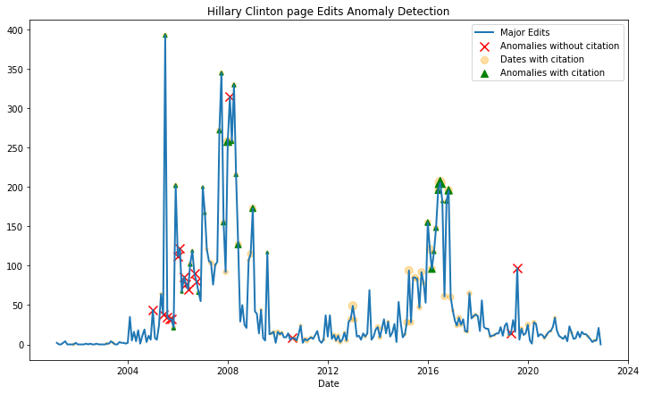

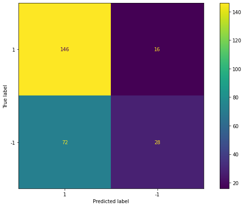

```
Precision: 0.64
Recall: 0.28
F1 Score: 0.39
Average number of citation for predicted dates 2.05

--------------------------------------------------
Barack Obama Page Model
--------------------------------------------------
```

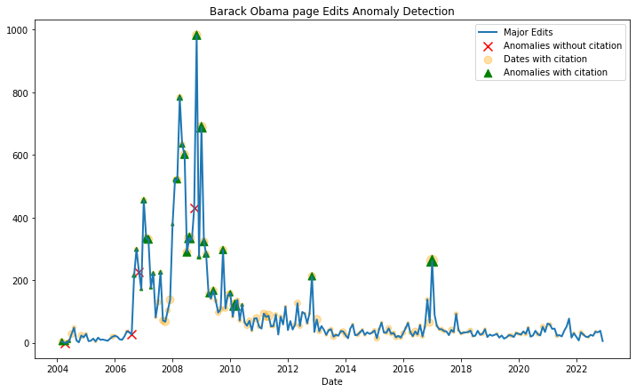

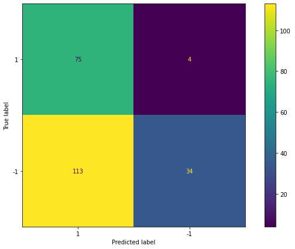

```
Precision: 0.89
Recall: 0.23
F1 Score: 0.37
Average number of citation for predicted dates 4.74

--------------------------------------------------
Chuck Schumer Page Model
--------------------------------------------------
```

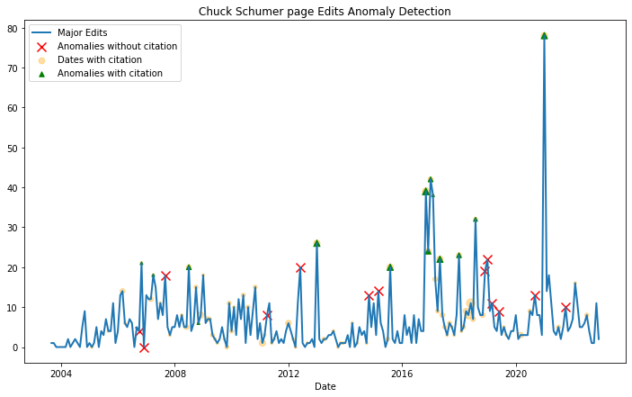

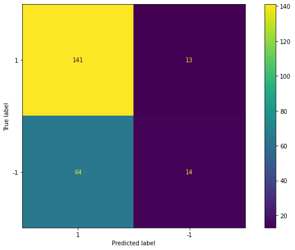

```
Precision: 0.52
Recall: 0.18
F1 Score: 0.27
Average number of citation for predicted dates 1.67

--------------------------------------------------
Mitch McConnell Page Model
--------------------------------------------------
```

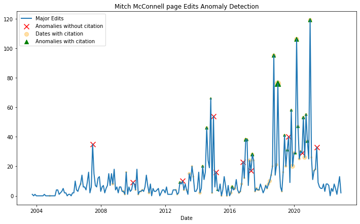

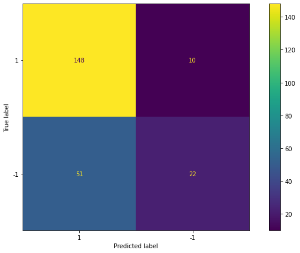

```
Precision: 0.69
Recall: 0.30
F1 Score: 0.42
Average number of citation for predicted dates 2.25
```

```python
sum_precision = 0
sum_recall = 0
sum_F1 = 0
sum_avg_predicted = 0

for page in page_names:
    print('\n'+'-'*50)
    print(' '.join(page.split('_'))+ ' Page Model')
    print('-'*50)
    df = dict_of_tables[page]
    X = np.array(df[['Major','Minor edits']])
    # Fit Isolation Forest Model
    clf = IsolationForest(random_state=0).fit(X)
    # Predict
    anomaly_predicted =  clf.predict(X)
    predicted = df[anomaly_predicted == -1]

    # Define important class
    y_important = [(-1)**int(x) for x in df['Total Found']!=0]

    # Plot predicted dates
    fig, ax = plt.subplots()
    ax.plot(df['Month'], df['Major'],linestyle='-', linewidth=2.0)
    ax.scatter(predicted[predicted['Total Found']==0]['Month'], predicted[predicted['Total Found']==0]['Major'],
           s=100,marker='x', c ='red'  )
    ax.scatter(df['Month'], df['Major'],
           s = df['Total Found']*10,marker='o', c ='orange',alpha=0.35  )
    ax.scatter(predicted['Month'], predicted['Major'],
           s = predicted['Total Found']*10,marker='^', c ='green'  )
    plt.legend(['Major Edits','Anomalies without citation','Dates with citation','Anomalies with citation'])
    plt.xlabel('Date')
    plt.title(' '.join(page.split('_'))+' page Edits Anomaly Detection')
    plt.show()


    cm = confusion_matrix(y_important, anomaly_predicted, labels =[1,-1])
    disp = ConfusionMatrixDisplay(confusion_matrix=cm ,display_labels =[1,-1])
    disp.plot()
    plt.show()

    recall = cm[1,1] / np.sum(cm, axis = 1)[1]
    precision = cm[1,1] / np.sum(cm, axis = 0)[1]
    F1_score = 2*(precision*recall)/(precision+recall)
    print(f'Precision: {precision:.2f}')
    print(f'Recall: {recall:.2f}')
    print(f'F1 Score: {F1_score:.2f}')

    sum_precision += precision
    sum_recall += recall
    sum_F1 += F1_score
    pred_average=predicted['Total Found'].mean()
    sum_avg_predicted += pred_average
    print(f'Average number of citation for predicted dates {pred_average:.2f}')
```

```python
avg_precision = sum_precision/len(page_names)
avg_recall = sum_recall/len(page_names)
avg_F1 = sum_F1/len(page_names)
avg_avg_predicted = sum_avg_predicted/len(page_names)

print(f'Average Precision: {avg_precision:.2f}')
print(f'Average Recall: {avg_recall:.2f}')
print(f'Average F1 Score: {avg_F1:.2f}')

print(f'Average number of citation for predicted dates {avg_avg_predicted:.2f}')
```

```
Average Precision: 0.76
Average Recall: 0.26
Average F1 Score: 0.38
Average number of citation for predicted dates 4.18
```

## Conclusion and Future Work

Wikipedia page edit trends for political figures does appear to indicate *important* events. Visual, examining each time series one can observe that during periods where many edits occur, there many citations appear for those dates. This suggests that edits are occuring to reflect the recent news. Moreover, we have that they are indeed statstistically correlated. That is, the number of page edits is positivly correlated with the number of citations for that particular date.